```python
!pip install --upgrade pandas
```

[output not shown]

By Ghiffary Rifqialdi

# *Exploratory Data Analysis: Preparation and Imputation*

[Analisis Data Eksplorasi](https://en.wikipedia.org/wiki/Exploratory_data_analysis), sering disingkat menjadi EDA, adalah istilah yang akan sering Anda dengar di bidang ilmu data. EDA adalah proses pemeriksaan kumpulan data untuk menemukan fakta tentang data dan mengkomunikasikan fakta tersebut, seringkali melalui visualisasi.

Untuk mengeksplorasi data dan memvisualisasikannya, beberapa modifikasi mungkin perlu dilakukan pada data. Hal ini sering disebut sebagai *data preparation*.

*Data preparation* adalah proses-proses pengumpulan (collecting), pembersihan (cleaning), dan penyatuan (consolidating) data ke dalam sebuah file atau tabel data untuk keperluan analisis.

*Data preparation* umumnya dilakukan karena

- Data berasal dari beberapa sumber
- Data berasal dari input yang manual
- Data berantakan, tidak konsisten, dan/atau tidak terstandarisasi strukturnya
- Data berasal dari sumber data tidak terstruktur, seperti dokumen PDF

Mengapa *data preparation* harus dilakukan?

**Garbage In, Garbage Out**

[figure not shown]

Secanggih apapun tools pemodelan dan analisis, apabila diberikan terlalu banyak data input yang “kotor”, model dan analisis yang dihasilkan juga akan terkontaminasi.

## Pengambilan Data

Data titanic merupakan dataset yang berasal dari kompetisi machine learning yang legendaris. Tujuan kompetisi tersebut dahulunya untuk memprediksi penumpang yang selamat dari tenggelamnya kapal titanic.

Dataset ini terdapat di kaggle dengan link https://www.kaggle.com/c/titanic yang terdiri dari

- train.csv (data for a subset of the passengers * including outcomes (survived or perished))
- test.csv (data for a subset of passengers without outcomes)

Data description:

- Survival - Survival (0 = No; 1 = Yes). Not included in test.csv file.
- Pclass - Passenger Class (1 = 1st; 2 = 2nd; 3 = 3rd)
- Name - Name
- Sex - Sex
- Age - Age
- Sibsp - Number of Siblings/Spouses Aboard
- Parch - Number of Parents/Children Aboard
- Ticket - Ticket Number
- Fare - Passenger Fare
- Cabin - Cabin
- Embarked - Port of Embarkation (C = Cherbourg; Q = Queenstown; S = Southampton)

```python
!chmod 600 kaggle.json && (ls ~/.kaggle 2>/dev/null || mkdir ~/.kaggle) && mv kaggle.json ~/.kaggle/ && echo 'Done'
```

```
Done
```

```python
!kaggle competitions download -c titanic
```

## Pendahuluan Dataset

```python
import pandas as pd
import warnings
warnings.filterwarnings("ignore")
pd.set_option('display.max_column', None)
pd.set_option('display.max_rows', None)
pd.set_option('display.max_seq_items', None)
pd.set_option('display.max_colwidth', 500)
pd.set_option('expand_frame_repr', True)

train = pd.read_csv('/content/train.csv')
test = pd.read_csv('/content/test.csv')

print('Training data shape: ', train.shape)
print('Testing data shape: ', test.shape)
```

```
Training data shape:  (891, 12)
Testing data shape:  (418, 11)
```

```python
train.head()
```

|  | PassengerId | Survived | Pclass | Name | Sex | Age | SibSp | Parch | Ticket | Fare | Cabin | Embarked |
| --- | --- | --- | --- | --- | --- | --- | --- | --- | --- | --- | --- | --- |
| 0 | 1 | 0 | 3 | Braund, Mr. Owen Harris | male | 22.0 | 1 | 0 | A/5 21171 | 7.2500 | NaN | S |
| 1 | 2 | 1 | 1 | Cumings, Mrs. John Bradley (Florence Briggs Thayer) | female | 38.0 | 1 | 0 | PC 17599 | 71.2833 | C85 | C |
| 2 | 3 | 1 | 3 | Heikkinen, Miss. Laina | female | 26.0 | 0 | 0 | STON/O2. 3101282 | 7.9250 | NaN | S |
| 3 | 4 | 1 | 1 | Futrelle, Mrs. Jacques Heath (Lily May Peel) | female | 35.0 | 1 | 0 | 113803 | 53.1000 | C123 | S |
| 4 | 5 | 0 | 3 | Allen, Mr. William Henry | male | 35.0 | 0 | 0 | 373450 | 8.0500 | NaN | S |

```python
train.info(verbose=True, null_counts=True)
```

```
<class 'pandas.core.frame.DataFrame'>
RangeIndex: 891 entries, 0 to 890
Data columns (total 12 columns):
 #   Column       Non-Null Count  Dtype
---  ------       --------------  -----
 0   PassengerId  891 non-null    int64
 1   Survived     891 non-null    int64
 2   Pclass       891 non-null    int64
 3   Name         891 non-null    object
 4   Sex          891 non-null    object
 5   Age          714 non-null    float64
 6   SibSp        891 non-null    int64
 7   Parch        891 non-null    int64
 8   Ticket       891 non-null    object
 9   Fare         891 non-null    float64
 10  Cabin        204 non-null    object
 11  Embarked     889 non-null    object
dtypes: float64(2), int64(5), object(5)
memory usage: 83.7+ KB
```

```python
test.head()
```

|  | PassengerId | Pclass | Name | Sex | Age | SibSp | Parch | Ticket | Fare | Cabin | Embarked |
| --- | --- | --- | --- | --- | --- | --- | --- | --- | --- | --- | --- |
| 0 | 892 | 3 | Kelly, Mr. James | male | 34.5 | 0 | 0 | 330911 | 7.8292 | NaN | Q |
| 1 | 893 | 3 | Wilkes, Mrs. James (Ellen Needs) | female | 47.0 | 1 | 0 | 363272 | 7.0000 | NaN | S |
| 2 | 894 | 2 | Myles, Mr. Thomas Francis | male | 62.0 | 0 | 0 | 240276 | 9.6875 | NaN | Q |
| 3 | 895 | 3 | Wirz, Mr. Albert | male | 27.0 | 0 | 0 | 315154 | 8.6625 | NaN | S |
| 4 | 896 | 3 | Hirvonen, Mrs. Alexander (Helga E Lindqvist) | female | 22.0 | 1 | 1 | 3101298 | 12.2875 | NaN | S |

```python
test.info(verbose=True, null_counts=True)
```

```
<class 'pandas.core.frame.DataFrame'>
RangeIndex: 418 entries, 0 to 417
Data columns (total 11 columns):
 #   Column       Non-Null Count  Dtype
---  ------       --------------  -----
 0   PassengerId  418 non-null    int64
 1   Pclass       418 non-null    int64
 2   Name         418 non-null    object
 3   Sex          418 non-null    object
 4   Age          332 non-null    float64
 5   SibSp        418 non-null    int64
 6   Parch        418 non-null    int64
 7   Ticket       418 non-null    object
 8   Fare         417 non-null    float64
 9   Cabin        91 non-null     object
 10  Embarked     418 non-null    object
dtypes: float64(2), int64(4), object(5)
memory usage: 36.0+ KB
```

## Train Test Split

Misalkan kita membuat suatu dataset kemudian fitur dan label dipisahkan

```python
dataset_X = train.drop(labels='Survived', axis=1)
dataset_X.head()
```

|  | PassengerId | Pclass | Name | Sex | Age | SibSp | Parch | Ticket | Fare | Cabin | Embarked |
| --- | --- | --- | --- | --- | --- | --- | --- | --- | --- | --- | --- |
| 0 | 1 | 3 | Braund, Mr. Owen Harris | male | 22.0 | 1 | 0 | A/5 21171 | 7.2500 | NaN | S |
| 1 | 2 | 1 | Cumings, Mrs. John Bradley (Florence Briggs Thayer) | female | 38.0 | 1 | 0 | PC 17599 | 71.2833 | C85 | C |
| 2 | 3 | 3 | Heikkinen, Miss. Laina | female | 26.0 | 0 | 0 | STON/O2. 3101282 | 7.9250 | NaN | S |
| 3 | 4 | 1 | Futrelle, Mrs. Jacques Heath (Lily May Peel) | female | 35.0 | 1 | 0 | 113803 | 53.1000 | C123 | S |
| 4 | 5 | 3 | Allen, Mr. William Henry | male | 35.0 | 0 | 0 | 373450 | 8.0500 | NaN | S |

```python
dataset_y = train['Survived']
dataset_y.head()
```

```
0    0
1    1
2    1
3    1
4    0
Name: Survived, dtype: int64
```

```python
from sklearn.model_selection import train_test_split

X_train, X_test, y_train, y_test = train_test_split(dataset_X, dataset_y, train_size=0.8, random_state=0)
```

```python
len(dataset_X)
```

```
891
```

```python
len(X_train)/len(dataset_X)
```

```
0.7991021324354658
```

```python
len(X_test)/len(dataset_X)
```

```
0.20089786756453423
```

## Penggabungan Data

Jika ada lebih dari satu dataset yang ingin digabungkan maka perlu dilakukan penggabungan

### Concat

Digunakan untuk menambahkan satu (atau lebih) dataframes satu di bawah yang lain (atau ke samping, tergantung pada apakah axis opsi ini diatur ke 0 atau 1).

Dengan cara menggabungkan DataFrames di seluruh baris atau kolom.

[figure not shown]

```python
result_concat = pd.concat([train, test], axis=0) # jumlah barisnya jadi digabungkan
result_concat.head()
```

|  | PassengerId | Survived | Pclass | Name | Sex | Age | SibSp | Parch | Ticket | Fare | Cabin | Embarked |
| --- | --- | --- | --- | --- | --- | --- | --- | --- | --- | --- | --- | --- |
| 0 | 1 | 0.0 | 3 | Braund, Mr. Owen Harris | male | 22.0 | 1 | 0 | A/5 21171 | 7.2500 | NaN | S |
| 1 | 2 | 1.0 | 1 | Cumings, Mrs. John Bradley (Florence Briggs Thayer) | female | 38.0 | 1 | 0 | PC 17599 | 71.2833 | C85 | C |
| 2 | 3 | 1.0 | 3 | Heikkinen, Miss. Laina | female | 26.0 | 0 | 0 | STON/O2. 3101282 | 7.9250 | NaN | S |
| 3 | 4 | 1.0 | 1 | Futrelle, Mrs. Jacques Heath (Lily May Peel) | female | 35.0 | 1 | 0 | 113803 | 53.1000 | C123 | S |
| 4 | 5 | 0.0 | 3 | Allen, Mr. William Henry | male | 35.0 | 0 | 0 | 373450 | 8.0500 | NaN | S |

```python
result_concat.info(verbose=True, null_counts=True)
```

```
<class 'pandas.core.frame.DataFrame'>
Int64Index: 1309 entries, 0 to 417
Data columns (total 12 columns):
 #   Column       Non-Null Count  Dtype
---  ------       --------------  -----
 0   PassengerId  1309 non-null   int64
 1   Survived     891 non-null    float64
 2   Pclass       1309 non-null   int64
 3   Name         1309 non-null   object
 4   Sex          1309 non-null   object
 5   Age          1046 non-null   float64
 6   SibSp        1309 non-null   int64
 7   Parch        1309 non-null   int64
 8   Ticket       1309 non-null   object
 9   Fare         1308 non-null   float64
 10  Cabin        295 non-null    object
 11  Embarked     1307 non-null   object
dtypes: float64(3), int64(4), object(5)
memory usage: 132.9+ KB
```

### Merge

Digunakan untuk menggabungkan dua (atau lebih) dataframes atas dasar nilai-nilai dari kolom umum (indeks juga dapat digunakan, gunakan left_index=True dan/atau right_index=True)

Menggabungkan data pada kolom atau indeks yang umum.

[figure not shown]

```python
df_temp1 = train[['PassengerId', 'Survived']]
df_temp2 = train[['PassengerId', 'Pclass']]
```

```python
len(df_temp2)
```

```
891
```

```python
df_temp1.head()
```

|  | PassengerId | Survived |
| --- | --- | --- |
| 0 | 1 | 0 |
| 1 | 2 | 1 |
| 2 | 3 | 1 |
| 3 | 4 | 1 |
| 4 | 5 | 0 |

```python
df_temp2.drop(labels=1, axis=0, inplace=True)
df_temp2.head()
```

|  | PassengerId | Pclass |
| --- | --- | --- |
| 0 | 1 | 3 |
| 2 | 3 | 3 |
| 3 | 4 | 1 |
| 4 | 5 | 3 |
| 5 | 6 | 3 |

```python
len(df_temp2)
```

```
890
```

```python
result_merge = pd.merge(df_temp1, df_temp2, on='PassengerId', how='inner')
result_merge.head()
```

|  | PassengerId | Survived | Pclass |
| --- | --- | --- | --- |
| 0 | 1 | 0 | 3 |
| 1 | 3 | 1 | 3 |
| 2 | 4 | 1 | 1 |
| 3 | 5 | 0 | 3 |
| 4 | 6 | 0 | 3 |

```python
result_merge.info(verbose=True, null_counts=True)
```

```
<class 'pandas.core.frame.DataFrame'>
Int64Index: 890 entries, 0 to 889
Data columns (total 3 columns):
 #   Column       Non-Null Count  Dtype
---  ------       --------------  -----
 0   PassengerId  890 non-null    int64
 1   Survived     890 non-null    int64
 2   Pclass       890 non-null    int64
dtypes: int64(3)
memory usage: 27.8 KB
```

### Join

Digunakan untuk menggabungkan 2 dataframes atas dasar indeks; alih-alih menggunakan merge() dengan opsi left_index=True

Menggabungkan data pada kolom atau indeks.

[figure not shown]

```python
df_temp1 = train[0:5]
df_temp2 = train[4:9]
```

```python
df_temp1
```

|  | PassengerId | Survived | Pclass | Name | Sex | Age | SibSp | Parch | Ticket | Fare | Cabin | Embarked |
| --- | --- | --- | --- | --- | --- | --- | --- | --- | --- | --- | --- | --- |
| 0 | 1 | 0 | 3 | Braund, Mr. Owen Harris | male | 22.0 | 1 | 0 | A/5 21171 | 7.2500 | NaN | S |
| 1 | 2 | 1 | 1 | Cumings, Mrs. John Bradley (Florence Briggs Thayer) | female | 38.0 | 1 | 0 | PC 17599 | 71.2833 | C85 | C |
| 2 | 3 | 1 | 3 | Heikkinen, Miss. Laina | female | 26.0 | 0 | 0 | STON/O2. 3101282 | 7.9250 | NaN | S |
| 3 | 4 | 1 | 1 | Futrelle, Mrs. Jacques Heath (Lily May Peel) | female | 35.0 | 1 | 0 | 113803 | 53.1000 | C123 | S |
| 4 | 5 | 0 | 3 | Allen, Mr. William Henry | male | 35.0 | 0 | 0 | 373450 | 8.0500 | NaN | S |

```python
df_temp2
```

|  | PassengerId | Survived | Pclass | Name | Sex | Age | SibSp | Parch | Ticket | Fare | Cabin | Embarked |
| --- | --- | --- | --- | --- | --- | --- | --- | --- | --- | --- | --- | --- |
| 4 | 5 | 0 | 3 | Allen, Mr. William Henry | male | 35.0 | 0 | 0 | 373450 | 8.0500 | NaN | S |
| 5 | 6 | 0 | 3 | Moran, Mr. James | male | NaN | 0 | 0 | 330877 | 8.4583 | NaN | Q |
| 6 | 7 | 0 | 1 | McCarthy, Mr. Timothy J | male | 54.0 | 0 | 0 | 17463 | 51.8625 | E46 | S |
| 7 | 8 | 0 | 3 | Palsson, Master. Gosta Leonard | male | 2.0 | 3 | 1 | 349909 | 21.0750 | NaN | S |
| 8 | 9 | 1 | 3 | Johnson, Mrs. Oscar W (Elisabeth Vilhelmina Berg) | female | 27.0 | 0 | 2 | 347742 | 11.1333 | NaN | S |

```python
result_join = df_temp1.join(df_temp2, on='PassengerId', how='inner', lsuffix='_left', rsuffix='_right')
result_join
```

|  | PassengerId | PassengerId_left | Survived_left | Pclass_left | Name_left | Sex_left | Age_left | SibSp_left | Parch_left | Ticket_left | Fare_left | Cabin_left | Embarked_left | PassengerId_right | Survived_right | Pclass_right | Name_right | Sex_right | Age_right | SibSp_right | Parch_right | Ticket_right | Fare_right | Cabin_right | Embarked_right |
| --- | --- | --- | --- | --- | --- | --- | --- | --- | --- | --- | --- | --- | --- | --- | --- | --- | --- | --- | --- | --- | --- | --- | --- | --- | --- |
| 3 | 4 | 4 | 1 | 1 | Futrelle, Mrs. Jacques Heath (Lily May Peel) | female | 35.0 | 1 | 0 | 113803 | 53.10 | C123 | S | 5 | 0 | 3 | Allen, Mr. William Henry | male | 35.0 | 0 | 0 | 373450 | 8.0500 | NaN | S |
| 4 | 5 | 5 | 0 | 3 | Allen, Mr. William Henry | male | 35.0 | 0 | 0 | 373450 | 8.05 | NaN | S | 6 | 0 | 3 | Moran, Mr. James | male | NaN | 0 | 0 | 330877 | 8.4583 | NaN | Q |

```python
result_join.info(verbose=True, null_counts=True)
```

```
<class 'pandas.core.frame.DataFrame'>
Int64Index: 2 entries, 3 to 4
Data columns (total 25 columns):
 #   Column             Non-Null Count  Dtype
---  ------             --------------  -----
 0   PassengerId        2 non-null      int64
 1   PassengerId_left   2 non-null      int64
 2   Survived_left      2 non-null      int64
 3   Pclass_left        2 non-null      int64
 4   Name_left          2 non-null      object
 5   Sex_left           2 non-null      object
 6   Age_left           2 non-null      float64
 7   SibSp_left         2 non-null      int64
 8   Parch_left         2 non-null      int64
 9   Ticket_left        2 non-null      object
```

[output cut: 17 more lines]

## Data Duplikat

Mengecek data duplikat

```python
duplicate = train.duplicated().sum()
print("Jumlah duplikat: ", duplicate)
```

```
Jumlah duplikat:  0
```

Jika ada duplikat, bisa dicek menggunakan sintaks ini

```python
show_duplicate = train.loc[train.duplicated(keep=False),:]
show_duplicate.head()
```

|  | PassengerId | Survived | Pclass | Name | Sex | Age | SibSp | Parch | Ticket | Fare | Cabin | Embarked |
| --- | --- | --- | --- | --- | --- | --- | --- | --- | --- | --- | --- | --- |

Jika ada duplikat, bisa dipilih salah satu data saja

```python
train_no_duplicate = train.drop_duplicates(keep='first')
train_no_duplicate.shape
```

```
(891, 12)
```

## Filtering Data

Menampilkan dataframe penumpang pria

```python
train_male = train[train['Sex']=='male']
train_male.head()
```

|  | PassengerId | Survived | Pclass | Name | Sex | Age | SibSp | Parch | Ticket | Fare | Cabin | Embarked |
| --- | --- | --- | --- | --- | --- | --- | --- | --- | --- | --- | --- | --- |
| 0 | 1 | 0 | 3 | Braund, Mr. Owen Harris | male | 22.0 | 1 | 0 | A/5 21171 | 7.2500 | NaN | S |
| 4 | 5 | 0 | 3 | Allen, Mr. William Henry | male | 35.0 | 0 | 0 | 373450 | 8.0500 | NaN | S |
| 5 | 6 | 0 | 3 | Moran, Mr. James | male | NaN | 0 | 0 | 330877 | 8.4583 | NaN | Q |
| 6 | 7 | 0 | 1 | McCarthy, Mr. Timothy J | male | 54.0 | 0 | 0 | 17463 | 51.8625 | E46 | S |
| 7 | 8 | 0 | 3 | Palsson, Master. Gosta Leonard | male | 2.0 | 3 | 1 | 349909 | 21.0750 | NaN | S |

```python
train_male.info(verbose=True, null_counts=True)
```

```
<class 'pandas.core.frame.DataFrame'>
Int64Index: 577 entries, 0 to 890
Data columns (total 12 columns):
 #   Column       Non-Null Count  Dtype
---  ------       --------------  -----
 0   PassengerId  577 non-null    int64
 1   Survived     577 non-null    int64
 2   Pclass       577 non-null    int64
 3   Name         577 non-null    object
 4   Sex          577 non-null    object
 5   Age          453 non-null    float64
 6   SibSp        577 non-null    int64
 7   Parch        577 non-null    int64
 8   Ticket       577 non-null    object
 9   Fare         577 non-null    float64
 10  Cabin        107 non-null    object
 11  Embarked     577 non-null    object
dtypes: float64(2), int64(5), object(5)
memory usage: 58.6+ KB
```

```python
train_male = train_male.reset_index()
```

```python
train_male.info(verbose=True, null_counts=True)
```

```
<class 'pandas.core.frame.DataFrame'>
RangeIndex: 577 entries, 0 to 576
Data columns (total 13 columns):
 #   Column       Non-Null Count  Dtype
---  ------       --------------  -----
 0   index        577 non-null    int64
 1   PassengerId  577 non-null    int64
 2   Survived     577 non-null    int64
 3   Pclass       577 non-null    int64
 4   Name         577 non-null    object
 5   Sex          577 non-null    object
 6   Age          453 non-null    float64
 7   SibSp        577 non-null    int64
 8   Parch        577 non-null    int64
 9   Ticket       577 non-null    object
 10  Fare         577 non-null    float64
 11  Cabin        107 non-null    object
 12  Embarked     577 non-null    object
dtypes: float64(2), int64(6), object(5)
memory usage: 58.7+ KB
```

Menampilkan data penumpang berumur antara 17 sampai 30 tahun

```python
train_age = train[(train['Age']<30) & (train['Age']>17)]
train_age.head()
```

|  | PassengerId | Survived | Pclass | Name | Sex | Age | SibSp | Parch | Ticket | Fare | Cabin | Embarked |
| --- | --- | --- | --- | --- | --- | --- | --- | --- | --- | --- | --- | --- |
| 0 | 1 | 0 | 3 | Braund, Mr. Owen Harris | male | 22.0 | 1 | 0 | A/5 21171 | 7.2500 | NaN | S |
| 2 | 3 | 1 | 3 | Heikkinen, Miss. Laina | female | 26.0 | 0 | 0 | STON/O2. 3101282 | 7.9250 | NaN | S |
| 8 | 9 | 1 | 3 | Johnson, Mrs. Oscar W (Elisabeth Vilhelmina Berg) | female | 27.0 | 0 | 2 | 347742 | 11.1333 | NaN | S |
| 12 | 13 | 0 | 3 | Saundercock, Mr. William Henry | male | 20.0 | 0 | 0 | A/5. 2151 | 8.0500 | NaN | S |
| 23 | 24 | 1 | 1 | Sloper, Mr. William Thompson | male | 28.0 | 0 | 0 | 113788 | 35.5000 | A6 | S |

```python
train_age.info(verbose=True, null_counts=True)
```

```
<class 'pandas.core.frame.DataFrame'>
Int64Index: 271 entries, 0 to 889
Data columns (total 12 columns):
 #   Column       Non-Null Count  Dtype
---  ------       --------------  -----
 0   PassengerId  271 non-null    int64
 1   Survived     271 non-null    int64
 2   Pclass       271 non-null    int64
 3   Name         271 non-null    object
 4   Sex          271 non-null    object
 5   Age          271 non-null    float64
 6   SibSp        271 non-null    int64
 7   Parch        271 non-null    int64
 8   Ticket       271 non-null    object
 9   Fare         271 non-null    float64
 10  Cabin        46 non-null     object
 11  Embarked     271 non-null    object
dtypes: float64(2), int64(5), object(5)
memory usage: 27.5+ KB
```

## Pre-processing Tipe Data

Data yang tidak dapat membantu memberikan insight atau memprediksi label (dalam hal ini 'Survived') di machine learning tidak dipakai

```python
# Untuk mengecek nilai unik setiap kolom sehingga kolom numerikal dan kategorikal dapat dibedakan

for column in train.columns:
  print(column)
  print(train[column].unique(), '\n')
```

[output not shown]

[output cut: 638 more lines]

```
 'B58 B60' 'E101' 'F E69' 'D47' 'B86' 'F2' 'C2' 'E33' 'B19' 'A7' 'C49'
 'F4' 'A32' 'B4' 'B80' 'A31' 'D36' 'D15' 'C93' 'C78' 'D35' 'C87' 'B77'
 'E67' 'B94' 'C125' 'C99' 'C118' 'D7' 'A19' 'B49' 'D' 'C22 C26' 'C106'
 'C65' 'E36' 'C54' 'B57 B59 B63 B66' 'C7' 'E34' 'C32' 'B18' 'C124' 'C91'
 'E40' 'T' 'C128' 'D37' 'B35' 'E50' 'C82' 'B96 B98' 'E10' 'E44' 'A34'
 'C104' 'C111' 'C92' 'E38' 'D21' 'E12' 'E63' 'A14' 'B37' 'C30' 'D20' 'B79'
 'E25' 'D46' 'B73' 'C95' 'B38' 'B39' 'B22' 'C86' 'C70' 'A16' 'C101' 'C68'
 'A10' 'E68' 'B41' 'A20' 'D19' 'D50' 'D9' 'A23' 'B50' 'A26' 'D48' 'E58'
 'C126' 'B71' 'B51 B53 B55' 'D49' 'B5' 'B20' 'F G63' 'C62 C64' 'E24' 'C90'
 'C45' 'E8' 'B101' 'D45' 'C46' 'D30' 'E121' 'D11' 'E77' 'F38' 'B3' 'D6'
 'B82 B84' 'D17' 'A36' 'B102' 'B69' 'E49' 'C47' 'D28' 'E17' 'A24' 'C50'
 'B42' 'C148']

Embarked
['S' 'C' 'Q' nan]
```

#### Data Numerikal

##### Eksplorasi Data Numerikal

```python
train.head()
```

|  | PassengerId | Survived | Pclass | Name | Sex | Age | SibSp | Parch | Ticket | Fare | Cabin | Embarked |
| --- | --- | --- | --- | --- | --- | --- | --- | --- | --- | --- | --- | --- |
| 0 | 1 | 0 | 3 | Braund, Mr. Owen Harris | male | 22.0 | 1 | 0 | A/5 21171 | 7.2500 | NaN | S |
| 1 | 2 | 1 | 1 | Cumings, Mrs. John Bradley (Florence Briggs Thayer) | female | 38.0 | 1 | 0 | PC 17599 | 71.2833 | C85 | C |
| 2 | 3 | 1 | 3 | Heikkinen, Miss. Laina | female | 26.0 | 0 | 0 | STON/O2. 3101282 | 7.9250 | NaN | S |
| 3 | 4 | 1 | 1 | Futrelle, Mrs. Jacques Heath (Lily May Peel) | female | 35.0 | 1 | 0 | 113803 | 53.1000 | C123 | S |
| 4 | 5 | 0 | 3 | Allen, Mr. William Henry | male | 35.0 | 0 | 0 | 373450 | 8.0500 | NaN | S |

```python
num_column = ['Age','Fare']
train_num = train.loc[:, num_column]
train_num.head()
```

|  | Age | Fare |
| --- | --- | --- |
| 0 | 22.0 | 7.2500 |
| 1 | 38.0 | 71.2833 |
| 2 | 26.0 | 7.9250 |
| 3 | 35.0 | 53.1000 |
| 4 | 35.0 | 8.0500 |

```python
'''
# Metode lain jika tipe data setiap kolom memang benar-benar data numerikal
columns=['int16', 'int32', 'int64', 'float16', 'float32', 'float64']
train_num = train.select_dtypes(include=columns)

# Alternatif lain
columns=['int16', 'int32', 'int64', 'float16', 'float32', 'float64']
train_num = train._get_numeric_data()
'''
```

```
"\n# Metode lain jika tipe data setiap kolom memang benar-benar data numerikal\ncolumns=['int16', 'int32', 'int64', 'float16', 'float32', 'float64']\ntrain_num = train.select_dtypes(include=columns)\n\n# Alternatif lain\ncolumns=['int16', 'int32', 'int64', 'float16', 'float32', 'float64']\ntrain_num…
```

###### Histogram

Untuk mengecek distribusi data

```python
train_num.columns
```

```
Index(['Age', 'Fare'], dtype='object')
```

```python
for column in train_num.columns:
  print(column)
```

```
Age
Fare
```

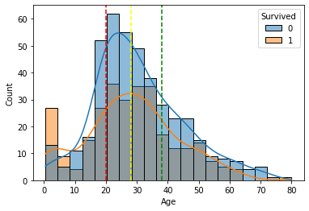

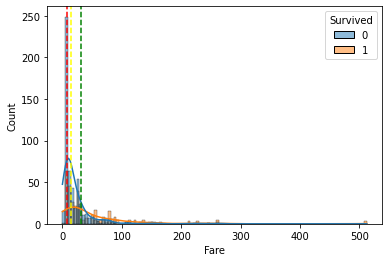

```python
import seaborn as sns
import matplotlib.pyplot as plt

for column in train_num.columns:
  sns.histplot(data=train, x=column, hue='Survived', kde=True)
  plt.axvline(x=train[column].quantile(0.25), ls='--', c='red', label='25')
  plt.axvline(x=train[column].quantile(0.5), ls='--', c='yellow', label='50')
  plt.axvline(x=train[column].quantile(0.75), ls='--', c='green', label='75')
  plt.show()
```

```python
train['Fare'].quantile(0.5)
```

```
14.4542
```

###### Box Plot

Analisis univariat untuk mengecek outlier

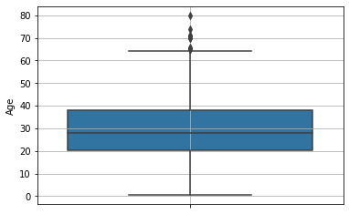

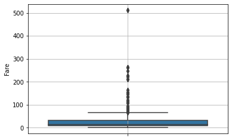

```python
for column in train_num.columns:
  sns.boxplot(y=column, data=train, orient='v')
  plt.grid(True)
  plt.show()
```

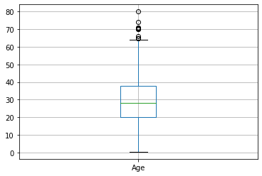

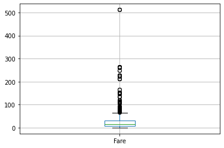

```python
# Alternatif lain
for column in train_num.columns:
  train.boxplot(column=column)
  plt.show()
```

##### Penanganan Pencilan (*Outlier*)

Pemilihan batas dilakukan dengan melihat distribusi data

###### Teknik Interkuartil

```python
def outliers_iqr(df, variable):
    Q1 = df[variable].quantile(0.25)
    Q3 = df[variable].quantile(0.75)
    IQR = Q3 - Q1
    upper_limit = Q3 + 1.5 * IQR
    lower_limit = Q1 - 1.5 * IQR
    return upper_limit, lower_limit
```

```python
import numpy as np

train_num_cap_iqr = train_num.copy(deep=True)
for column in train_num_cap_iqr.columns:
  upper_limit, _ =  outliers_iqr(train, column)
  lower_limit = 0
  train_num_cap_iqr[column] = np.where(train_num_cap_iqr[column]>upper_limit, upper_limit,
                          np.where(train_num_cap_iqr[column]<lower_limit, lower_limit,
                                   train_num_cap_iqr[column]))
  print(column)
  print("Upper whisker: ", upper_limit)
  print("Lower whisker: ", lower_limit, '\n')
```

```
Age
Upper whisker:  64.8125
Lower whisker:  0

Fare
Upper whisker:  65.6344
Lower whisker:  0
```

```python
# Contoh replace
# train_num_cap_iqr.loc[train_num_cap_iqr['Age']<=0] = 0
```

```python
print('before:')
print(train_num.describe())
print('\nafter:')
print(train_num_cap_iqr.describe())
```

```
before:
              Age        Fare
count  714.000000  891.000000
mean    29.699118   32.204208
std     14.526497   49.693429
min      0.420000    0.000000
25%     20.125000    7.910400
50%     28.000000   14.454200
75%     38.000000   31.000000
max     80.000000  512.329200

after:
              Age        Fare
count  714.000000  891.000000
mean    29.622700   24.046813
std     14.316665   20.481625
min      0.420000    0.000000
25%     20.125000    7.910400
50%     28.000000   14.454200
75%     38.000000   31.000000
max     64.812500   65.634400
```

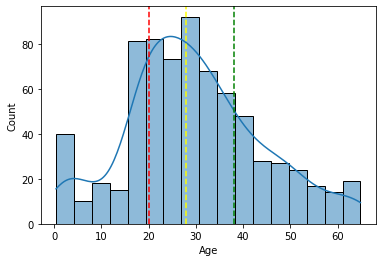

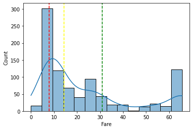

```python
train_num_before_after = [train_num, train_num_cap_iqr]
for data in train_num_before_after:
  for column in data.columns:
    sns.histplot(data=data, x=column, kde=True)
    plt.axvline(x=data[column].quantile(0.25), ls='--', c='red', label='25')
    plt.axvline(x=data[column].quantile(0.5), ls='--', c='yellow', label='50')
    plt.axvline(x=data[column].quantile(0.75), ls='--', c='green', label='75')
    plt.show()
```

###### Metode Standard Deviasi

```python
def outliers_std(df, variable):
    upper_limit = df[variable].mean() + 3 * df[variable].std()
    lower_limit = df[variable].mean() - 3 * df[variable].std()
    return upper_limit, lower_limit
```

```python
train_num_cap_std = train_num.copy(deep=True)
for column in train_num_cap_std.columns:
  upper_limit, _ =  outliers_std(train, column)
  lower_limit = 0
  train_num_cap_std[column] = np.where(train_num_cap_std[column]>=upper_limit, upper_limit,
                          np.where(train_num_cap_std[column]<=lower_limit, lower_limit,
                                   train_num_cap_std[column]))
  print(column)
  print("Upper whisker: ", upper_limit)
  print("Lower whisker: ", lower_limit, '\n')
```

```
Age
Upper whisker:  73.27860964406095
Lower whisker:  0

Fare
Upper whisker:  181.2844937601173
Lower whisker:  0
```

```python
print('before:')
print(train_num.describe())
print('\nafter:')
print(train_num_cap_std.describe())
```

```
before:
              Age        Fare
count  714.000000  891.000000
mean    29.699118   32.204208
std     14.526497   49.693429
min      0.420000    0.000000
25%     20.125000    7.910400
50%     28.000000   14.454200
75%     38.000000   31.000000
max     80.000000  512.329200

after:
              Age        Fare
count  714.000000  891.000000
mean    29.688694   30.003893
std     14.492933   36.989591
min      0.420000    0.000000
25%     20.125000    7.910400
50%     28.000000   14.454200
75%     38.000000   31.000000
max     73.278610  181.284494
```

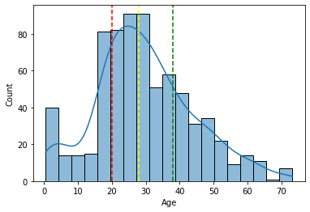

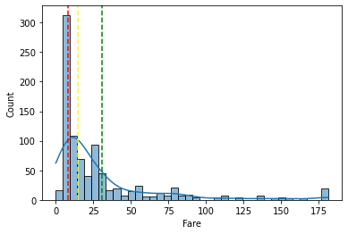

```python
train_num_before_after = [train_num, train_num_cap_std]
for data in train_num_before_after:
  for column in data.columns:
    sns.histplot(data=data, x=column, kde=True)
    plt.axvline(x=data[column].quantile(0.25), ls='--', c='red', label='25')
    plt.axvline(x=data[column].quantile(0.5), ls='--', c='yellow', label='50')
    plt.axvline(x=data[column].quantile(0.75), ls='--', c='green', label='75')
    plt.show()
```

###### Metode Z-score

```python
def outliers_zscore(df, variable):
    df = df.assign(z_score=(df[variable] - df[variable].mean()) / df[variable].std())
    upper_limit = df.loc[df['z_score'].sub(3).abs().idxmin()][variable]
    lower_limit = df.loc[df['z_score'].sub(-3).abs().idxmin()][variable]
    df.drop(labels='z_score', axis=1, inplace=True)
    return upper_limit, lower_limit
```

```python
train_num_cap_zscore = train_num.copy(deep=True)
for column in train_num_cap_zscore.columns:
  upper_limit, _ = outliers_zscore(train, column)
  lower_limit = 0
  train_num_cap_zscore[column] = np.where(train_num_cap_zscore[column]>=upper_limit, upper_limit,
                          np.where(train_num_cap_zscore[column]<=lower_limit, lower_limit,
                                   train_num_cap_zscore[column]))

  print(column)
  print("Upper whisker: ", upper_limit)
  print("Lower whisker: ", lower_limit, '\n')
```

```
Age
Upper whisker:  74.0
Lower whisker:  0

Fare
Upper whisker:  164.8667
Lower whisker:  0
```

```python
print('before:')
print(train_num.describe())
print('\nafter:')
print(train_num_cap_zscore.describe())
```

```
before:
              Age        Fare
count  714.000000  891.000000
mean    29.699118   32.204208
std     14.526497   49.693429
min      0.420000    0.000000
25%     20.125000    7.910400
50%     28.000000   14.454200
75%     38.000000   31.000000
max     80.000000  512.329200

after:
              Age        Fare
count  714.000000  891.000000
mean    29.690714   29.635367
std     14.499068   35.532019
min      0.420000    0.000000
25%     20.125000    7.910400
50%     28.000000   14.454200
75%     38.000000   31.000000
max     74.000000  164.866700
```

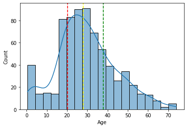

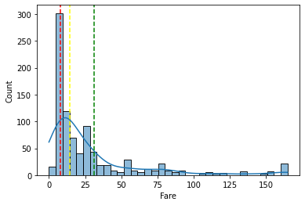

```python
train_num_before_after = [train_num, train_num_cap_zscore]
for data in train_num_before_after:
  for column in data.columns:
    sns.histplot(data=data, x=column, kde=True)
    plt.axvline(x=data[column].quantile(0.25), ls='--', c='red', label='25')
    plt.axvline(x=data[column].quantile(0.5), ls='--', c='yellow', label='50')
    plt.axvline(x=data[column].quantile(0.75), ls='--', c='green', label='75')
    plt.show()
```

##### Penskalaan Fitur (*Feature Scaling*)

###### *Min-Max Scaling*

[figure not shown]

Normalisasi baik digunakan distribusi data tidak mengikuti distribusi Gaussian. Metode ini berfungsi dengan baik untuk algoritme yang tidak mengasumsikan distribusi data apa pun, seperti K-Nearest Neighbors dan Neural Networks

```python
df_norm_mms = train_num_cap_std.copy(deep=True)
```

```python
%%time
from sklearn.preprocessing import MinMaxScaler

MMS = MinMaxScaler()
train_num_norm_mms = MMS.fit_transform(train_num_cap_std)
```

```
CPU times: user 5.96 ms, sys: 0 ns, total: 5.96 ms
Wall time: 6.42 ms
```

```python
df_norm_mms[train_num_cap_std.columns] = train_num_norm_mms
df_norm_mms.head()
```

|  | Age | Fare |
| --- | --- | --- |
| 0 | 0.296190 | 0.039992 |
| 1 | 0.515794 | 0.393212 |
| 2 | 0.351091 | 0.043716 |
| 3 | 0.474618 | 0.292910 |
| 4 | 0.474618 | 0.044405 |

```python
df_norm_mms.describe()
```

|  | Age | Fare |
| --- | --- | --- |
| count | 714.000000 | 891.000000 |
| mean | 0.401719 | 0.165507 |
| std | 0.198919 | 0.204042 |
| min | 0.000000 | 0.000000 |
| 25% | 0.270455 | 0.043635 |
| 50% | 0.378541 | 0.079732 |
| 75% | 0.515794 | 0.171002 |
| max | 1.000000 | 1.000000 |

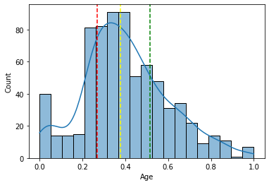

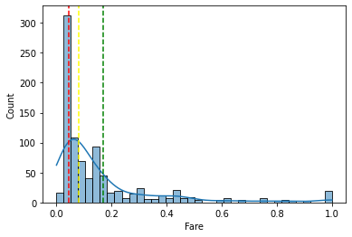

```python
import seaborn as sns
import matplotlib.pyplot as plt

train_num_before_after = [train_num, df_norm_mms]
for data in train_num_before_after:
  for column in data.columns:
    sns.histplot(data=data, x=column, kde=True)
    plt.axvline(x=data[column].quantile(0.25), ls='--', c='red', label='25')
    plt.axvline(x=data[column].quantile(0.5), ls='--', c='yellow', label='50')
    plt.axvline(x=data[column].quantile(0.75), ls='--', c='green', label='75')
    plt.show()
```

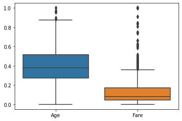

```python
train_num_before_after = [train_num, df_norm_mms]
for data in train_num_before_after:
  sns.boxplot(data=data, orient='v')
  plt.show()
```

###### Standardisasi

[figure not shown]

Standardisasi dapat membantu dalam kasus di mana data mengikuti distribusi Gaussian. Namun, hal ini bukanlah syarat mutlak. Selain itu, tidak seperti normalisasi, standardisasi tidak memiliki batasan jangkauan. Denagan demikian, bahkan jika Anda memiliki outlier dalam data Anda, mereka tidak akan terdampak oleh standardisasi.

```python
df_norm_std = train_num_cap_std.copy(deep=True)
```

```python
%%time
from sklearn.preprocessing import StandardScaler

SS = StandardScaler()
train_num_norm_std = SS.fit_transform(train_num_cap_std)
```

```
CPU times: user 6.45 ms, sys: 0 ns, total: 6.45 ms
Wall time: 6.93 ms
```

```python
df_norm_std[train_num_cap_std.columns] = train_num_norm_std
df_norm_std.head()
```

|  | Age | Fare |
| --- | --- | --- |
| 0 | -0.530885 | -0.615489 |
| 1 | 0.573875 | 1.116600 |
| 2 | -0.254695 | -0.597230 |
| 3 | 0.366733 | 0.624745 |
| 4 | 0.366733 | -0.593849 |

```python
df_norm_std.describe()
```

|  | Age | Fare |
| --- | --- | --- |
| count | 7.140000e+02 | 8.910000e+02 |
| mean | 1.639289e-16 | -6.678783e-17 |
| std | 1.000701e+00 | 1.000562e+00 |
| min | -2.020931e+00 | -8.115998e-01 |
| 25% | -6.603493e-01 | -5.976249e-01 |
| 50% | -1.166001e-01 | -4.206163e-01 |
| 75% | 5.738751e-01 | 2.694452e-02 |
| max | 3.009775e+00 | 4.092112e+00 |

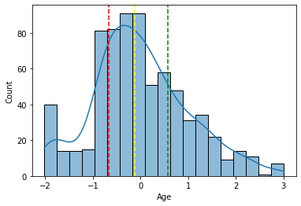

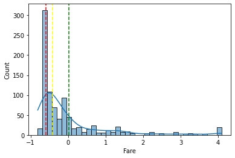

```python
import seaborn as sns
import matplotlib.pyplot as plt

train_num_before_after = [train_num, df_norm_std]
for data in train_num_before_after:
  for column in data.columns:
    sns.histplot(data=data, x=column, kde=True)
    plt.axvline(x=data[column].quantile(0.25), ls='--', c='red', label='25')
    plt.axvline(x=data[column].quantile(0.5), ls='--', c='yellow', label='50')
    plt.axvline(x=data[column].quantile(0.75), ls='--', c='green', label='75')
    plt.show()
```

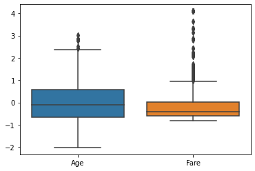

```python
train_num_before_after = [train_num, df_norm_std]
for data in train_num_before_after:
  sns.boxplot(data=data, orient='v')
  plt.show()
```

[figure not shown]

```python
df_norm_sig = train_num_cap_std.copy(deep=True)
```

```python
%%time
from tensorflow.math import sigmoid

df_norm_sig[train_num_cap_std.columns] = sigmoid(train_num_norm_std).numpy()
```

```
CPU times: user 2.21 s, sys: 263 ms, total: 2.47 s
Wall time: 2.6 s
```

```python
df_norm_sig[train_num_cap_std.columns] = train_num_norm_std
df_norm_sig.head()
```

|  | Age | Fare |
| --- | --- | --- |
| 0 | -0.530885 | -0.615489 |
| 1 | 0.573875 | 1.116600 |
| 2 | -0.254695 | -0.597230 |
| 3 | 0.366733 | 0.624745 |
| 4 | 0.366733 | -0.593849 |

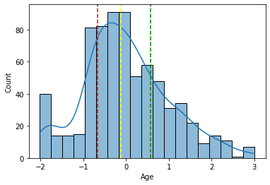

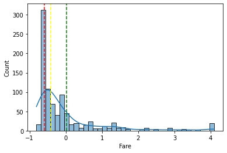

```python
import seaborn as sns
import matplotlib.pyplot as plt

train_num_before_after = [train_num, df_norm_sig]
for data in train_num_before_after:
  for column in data.columns:
    sns.histplot(data=data, x=column, kde=True)
    plt.axvline(x=data[column].quantile(0.25), ls='--', c='red', label='25')
    plt.axvline(x=data[column].quantile(0.5), ls='--', c='yellow', label='50')
    plt.axvline(x=data[column].quantile(0.75), ls='--', c='green', label='75')
    plt.show()
```

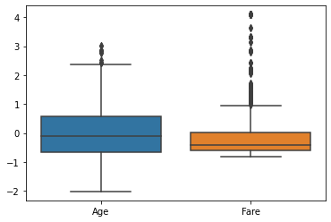

```python
train_num_before_after = [train_num, df_norm_sig]
for data in train_num_before_after:
  sns.boxplot(data=data, orient='v')
  plt.show()
```

###### Standardisasi dan Sigmoid

```python
df_norm_std_sig = train_num_cap_std.copy(deep=True)
```

```python
%%time
from sklearn.preprocessing import StandardScaler

SS = StandardScaler()
train_num_norm_std = SS.fit_transform(train_num_cap_std)
```

```
CPU times: user 6.66 ms, sys: 0 ns, total: 6.66 ms
Wall time: 7.73 ms
```

```python
%%time
from tensorflow.math import sigmoid

df_norm_std_sig[train_num_cap_std.columns] = sigmoid(train_num_norm_std).numpy()
```

```
CPU times: user 1.66 ms, sys: 0 ns, total: 1.66 ms
Wall time: 2.18 ms
```

```python
df_norm_std_sig.head()
```

|  | Age | Fare |
| --- | --- | --- |
| 0 | 0.370310 | 0.350808 |
| 1 | 0.639657 | 0.753358 |
| 2 | 0.436668 | 0.354978 |
| 3 | 0.590669 | 0.651297 |
| 4 | 0.590669 | 0.355752 |

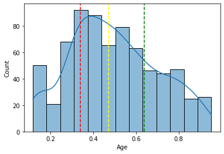

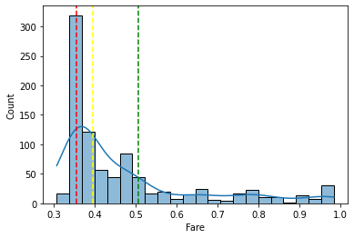

```python
import seaborn as sns
import matplotlib.pyplot as plt

train_num_before_after = [train_num, df_norm_std_sig]
for data in train_num_before_after:
  for column in data.columns:
    sns.histplot(data=data, x=column, kde=True)
    plt.axvline(x=data[column].quantile(0.25), ls='--', c='red', label='25')
    plt.axvline(x=data[column].quantile(0.5), ls='--', c='yellow', label='50')
    plt.axvline(x=data[column].quantile(0.75), ls='--', c='green', label='75')
    plt.show()
```

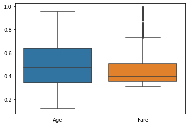

```python
train_num_before_after = [train_num, df_norm_std_sig]
for data in train_num_before_after:
  sns.boxplot(data=data, orient='v')
  plt.show()
```

#### Data Kategorikal

##### Eksplorasi Data Kategorikal

```python
train.head()
```

|  | PassengerId | Survived | Pclass | Name | Sex | Age | SibSp | Parch | Ticket | Fare | Cabin | Embarked |
| --- | --- | --- | --- | --- | --- | --- | --- | --- | --- | --- | --- | --- |
| 0 | 1 | 0 | 3 | Braund, Mr. Owen Harris | male | 22.0 | 1 | 0 | A/5 21171 | 7.2500 | NaN | S |
| 1 | 2 | 1 | 1 | Cumings, Mrs. John Bradley (Florence Briggs Thayer) | female | 38.0 | 1 | 0 | PC 17599 | 71.2833 | C85 | C |
| 2 | 3 | 1 | 3 | Heikkinen, Miss. Laina | female | 26.0 | 0 | 0 | STON/O2. 3101282 | 7.9250 | NaN | S |
| 3 | 4 | 1 | 1 | Futrelle, Mrs. Jacques Heath (Lily May Peel) | female | 35.0 | 1 | 0 | 113803 | 53.1000 | C123 | S |
| 4 | 5 | 0 | 3 | Allen, Mr. William Henry | male | 35.0 | 0 | 0 | 373450 | 8.0500 | NaN | S |

```python
cols = ['PassengerId', 'Name', 'Age', 'Ticket', 'Fare']
train_cat = train.loc[:, ~train.columns.isin(cols)]
train_cat.head()
```

|  | Survived | Pclass | Sex | SibSp | Parch | Cabin | Embarked |
| --- | --- | --- | --- | --- | --- | --- | --- |
| 0 | 0 | 3 | male | 1 | 0 | NaN | S |
| 1 | 1 | 1 | female | 1 | 0 | C85 | C |
| 2 | 1 | 3 | female | 0 | 0 | NaN | S |
| 3 | 1 | 1 | female | 1 | 0 | C123 | S |
| 4 | 0 | 3 | male | 0 | 0 | NaN | S |

```python
'''
# Metode lain jika tipe data setiap kolom memang benar-benar data string
train_cat = train.select_dtypes(include=object)
'''
```

```
'\n# Metode lain jika tipe data setiap kolom memang benar-benar data string\ntrain_cat = train.select_dtypes(include=object)\n'
```

###### Bar Plot

Untuk mengecek distribusi data kategorikal dan ketidakseimbangan data untuk label terpilih (*data imbalance*)

Kelas balance memiliki distribusi kategori target 50/50 atau 60/40. Jika tidak seimbang (misalnya 80/20) sebaiknya dilakukan weight balancing dipemodelan machine learning nantinya.

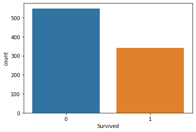

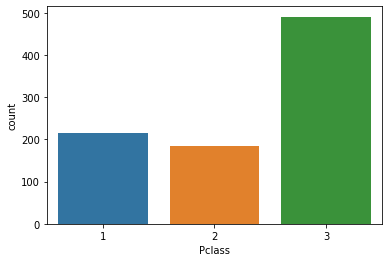

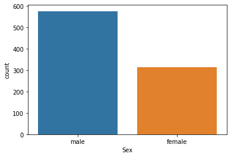

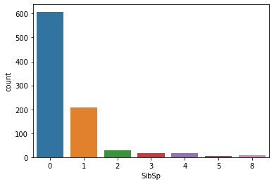

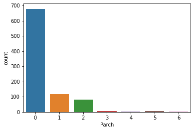

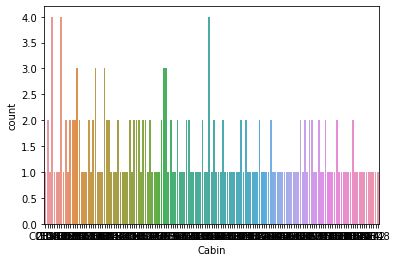

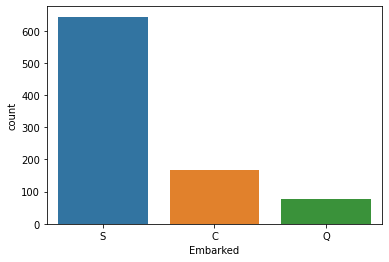

```python
for column in train_cat.columns:
  sns.countplot(data=train, x=column)
  plt.show()
```

##### Encoding

Encoding (atau remapping) dilakukan untuk mengubah nilai-nilai kategorikal ke bentuk numerik. Encoding perlu dilakukan terutama apabila data akan dianalisis dengan algoritma machine learning yang alaminya tidak dapat memproses nilai-nilai non-numerik, seperti neural network.

Metode label encoding mengganti setiap kategori dengan numerik secara langsung pada kolom data yang bersangkutan.

Metode one-hot encoding juga umum digunakan, yaitu dengan mengkonversi sebuah fitur menjadi fitur-fitur biner.

[figure not shown]

###### Label Encoding

```python
train_cat_LE = train_cat.copy(deep=True)
```

```python
train_cat_LE.head()
```

|  | Survived | Pclass | Sex | SibSp | Parch | Cabin | Embarked |
| --- | --- | --- | --- | --- | --- | --- | --- |
| 0 | 0 | 3 | male | 1 | 0 | NaN | S |
| 1 | 1 | 1 | female | 1 | 0 | C85 | C |
| 2 | 1 | 3 | female | 0 | 0 | NaN | S |
| 3 | 1 | 1 | female | 1 | 0 | C123 | S |
| 4 | 0 | 3 | male | 0 | 0 | NaN | S |

```python
from sklearn.preprocessing import LabelEncoder

LE_column = ['Sex', 'Cabin', 'Embarked']
for column in LE_column:
  LE = LabelEncoder()
  LE_column_encoded = LE.fit_transform(train_cat_LE[column])
  train_cat_LE[column] = LE_column_encoded
  print(column)
  print(train_cat[column].unique())
  print(LE.classes_)
  print(LE_column_encoded, '\n')
```

[output not shown]

[output cut: 122 more lines]

```python
train_cat_LE.head()
```

|  | Survived | Pclass | Sex | SibSp | Parch | Cabin | Embarked |
| --- | --- | --- | --- | --- | --- | --- | --- |
| 0 | 0 | 3 | 1 | 1 | 0 | 147 | 2 |
| 1 | 1 | 1 | 0 | 1 | 0 | 81 | 0 |
| 2 | 1 | 3 | 0 | 0 | 0 | 147 | 2 |
| 3 | 1 | 1 | 0 | 1 | 0 | 55 | 2 |
| 4 | 0 | 3 | 1 | 0 | 0 | 147 | 2 |

###### One Hot Encoding

```python
train_cat_OHE = train_cat.copy(deep=True)
```

```python
train_cat_OHE.head()
```

|  | Survived | Pclass | Sex | SibSp | Parch | Cabin | Embarked |
| --- | --- | --- | --- | --- | --- | --- | --- |
| 0 | 0 | 3 | male | 1 | 0 | NaN | S |
| 1 | 1 | 1 | female | 1 | 0 | C85 | C |
| 2 | 1 | 3 | female | 0 | 0 | NaN | S |
| 3 | 1 | 1 | female | 1 | 0 | C123 | S |
| 4 | 0 | 3 | male | 0 | 0 | NaN | S |

```python
train_cat_OHE.info(verbose=True, null_counts=True)
```

```
<class 'pandas.core.frame.DataFrame'>
RangeIndex: 891 entries, 0 to 890
Data columns (total 7 columns):
 #   Column    Non-Null Count  Dtype
---  ------    --------------  -----
 0   Survived  891 non-null    int64
 1   Pclass    891 non-null    int64
 2   Sex       891 non-null    object
 3   SibSp     891 non-null    int64
 4   Parch     891 non-null    int64
 5   Cabin     204 non-null    object
 6   Embarked  889 non-null    object
dtypes: int64(4), object(3)
memory usage: 48.9+ KB
```

```python
train_cat_OHE = pd.get_dummies(train_cat_OHE, columns=['Survived', 'Pclass', 'Sex', 'SibSp', 'Parch', 'Cabin', 'Embarked'], dummy_na=True)
```

```python
train_cat_OHE.head()
```

|  | Survived_0.0 | Survived_1.0 | Survived_nan | Pclass_1.0 | Pclass_2.0 | Pclass_3.0 | Pclass_nan | Sex_female | Sex_male | Sex_nan | SibSp_0.0 | SibSp_1.0 | SibSp_2.0 | SibSp_3.0 | SibSp_4.0 | SibSp_5.0 | SibSp_8.0 | SibSp_nan | Parch_0.0 | Parch_1.0 | Parch_2.0 | Parch_3.0 | Parch_4.0 | Parch_5.0 | Parch_6.0 | Parch_nan | Cabin_A10 | Cabin_A14 | Cabin_A16 | … |
| --- | --- | --- | --- | --- | --- | --- | --- | --- | --- | --- | --- | --- | --- | --- | --- | --- | --- | --- | --- | --- | --- | --- | --- | --- | --- | --- | --- | --- | --- | --- |
| 0 | 1 | 0 | 0 | 0 | 0 | 1 | 0 | 0 | 1 | 0 | 0 | 1 | 0 | 0 | 0 | 0 | 0 | 0 | 1 | 0 | 0 | 0 | 0 | 0 | 0 | 0 | 0 | 0 | 0 | … |
| 1 | 0 | 1 | 0 | 1 | 0 | 0 | 0 | 1 | 0 | 0 | 0 | 1 | 0 | 0 | 0 | 0 | 0 | 0 | 1 | 0 | 0 | 0 | 0 | 0 | 0 | 0 | 0 | 0 | 0 | … |
| 2 | 0 | 1 | 0 | 0 | 0 | 1 | 0 | 1 | 0 | 0 | 1 | 0 | 0 | 0 | 0 | 0 | 0 | 0 | 1 | 0 | 0 | 0 | 0 | 0 | 0 | 0 | 0 | 0 | 0 | … |
| 3 | 0 | 1 | 0 | 1 | 0 | 0 | 0 | 1 | 0 | 0 | 0 | 1 | 0 | 0 | 0 | 0 | 0 | 0 | 1 | 0 | 0 | 0 | 0 | 0 | 0 | 0 | 0 | 0 | 0 | … |
| 4 | 1 | 0 | 0 | 0 | 0 | 1 | 0 | 0 | 1 | 0 | 1 | 0 | 0 | 0 | 0 | 0 | 0 | 0 | 1 | 0 | 0 | 0 | 0 | 0 | 0 | 0 | 0 | 0 | 0 | … |

```python
nan_df = train_cat_OHE.loc[:, train_cat_OHE.columns.str.endswith("_nan")]
```

```python
nan_df.head()
```

|  | Survived_nan | Pclass_nan | Sex_nan | SibSp_nan | Parch_nan | Cabin_nan | Embarked_nan |
| --- | --- | --- | --- | --- | --- | --- | --- |
| 0 | 0 | 0 | 0 | 0 | 0 | 1 | 0 |
| 1 | 0 | 0 | 0 | 0 | 0 | 0 | 0 |
| 2 | 0 | 0 | 0 | 0 | 0 | 1 | 0 |
| 3 | 0 | 0 | 0 | 0 | 0 | 0 | 0 |
| 4 | 0 | 0 | 0 | 0 | 0 | 1 | 0 |

```python
import re

pattern = "^([^_]*)_"
regex = re.compile(pattern)

for index in train_cat_OHE.index:
    for col_nan in nan_df.columns:
        if train_cat_OHE.loc[index, col_nan] == 1:
            col_id = regex.search(col_nan).group(1)
            targets = train_cat_OHE.columns[train_cat_OHE.columns.str.startswith(col_id+'_')]
            train_cat_OHE.loc[index, targets] = np.nan
```

```python
train_cat_OHE.head()
```

|  | Survived_0.0 | Survived_1.0 | Survived_nan | Pclass_1.0 | Pclass_2.0 | Pclass_3.0 | Pclass_nan | Sex_female | Sex_male | Sex_nan | SibSp_0.0 | SibSp_1.0 | SibSp_2.0 | SibSp_3.0 | SibSp_4.0 | SibSp_5.0 | SibSp_8.0 | SibSp_nan | Parch_0.0 | Parch_1.0 | Parch_2.0 | Parch_3.0 | Parch_4.0 | Parch_5.0 | Parch_6.0 | Parch_nan | Cabin_A10 | Cabin_A14 | Cabin_A16 | … |
| --- | --- | --- | --- | --- | --- | --- | --- | --- | --- | --- | --- | --- | --- | --- | --- | --- | --- | --- | --- | --- | --- | --- | --- | --- | --- | --- | --- | --- | --- | --- |
| 0 | 1 | 0 | 0 | 0 | 0 | 1 | 0 | 0 | 1 | 0 | 0 | 1 | 0 | 0 | 0 | 0 | 0 | 0 | 1 | 0 | 0 | 0 | 0 | 0 | 0 | 0 | NaN | NaN | NaN | … |
| 1 | 0 | 1 | 0 | 1 | 0 | 0 | 0 | 1 | 0 | 0 | 0 | 1 | 0 | 0 | 0 | 0 | 0 | 0 | 1 | 0 | 0 | 0 | 0 | 0 | 0 | 0 | 0.0 | 0.0 | 0.0 | … |
| 2 | 0 | 1 | 0 | 0 | 0 | 1 | 0 | 1 | 0 | 0 | 1 | 0 | 0 | 0 | 0 | 0 | 0 | 0 | 1 | 0 | 0 | 0 | 0 | 0 | 0 | 0 | NaN | NaN | NaN | … |
| 3 | 0 | 1 | 0 | 1 | 0 | 0 | 0 | 1 | 0 | 0 | 0 | 1 | 0 | 0 | 0 | 0 | 0 | 0 | 1 | 0 | 0 | 0 | 0 | 0 | 0 | 0 | 0.0 | 0.0 | 0.0 | … |
| 4 | 1 | 0 | 0 | 0 | 0 | 1 | 0 | 0 | 1 | 0 | 1 | 0 | 0 | 0 | 0 | 0 | 0 | 0 | 1 | 0 | 0 | 0 | 0 | 0 | 0 | 0 | NaN | NaN | NaN | … |

```python
train_cat_OHE.drop(train_cat_OHE.columns[train_cat_OHE.columns.str.endswith('_nan')], axis=1, inplace=True)
```

```python
train_cat_OHE.head()
```

|  | Survived_0.0 | Survived_1.0 | Pclass_1.0 | Pclass_2.0 | Pclass_3.0 | Sex_female | Sex_male | SibSp_0.0 | SibSp_1.0 | SibSp_2.0 | SibSp_3.0 | SibSp_4.0 | SibSp_5.0 | SibSp_8.0 | Parch_0.0 | Parch_1.0 | Parch_2.0 | Parch_3.0 | Parch_4.0 | Parch_5.0 | Parch_6.0 | Cabin_A10 | Cabin_A14 | Cabin_A16 | Cabin_A19 | Cabin_A20 | Cabin_A23 | Cabin_A24 | Cabin_A26 | … |
| --- | --- | --- | --- | --- | --- | --- | --- | --- | --- | --- | --- | --- | --- | --- | --- | --- | --- | --- | --- | --- | --- | --- | --- | --- | --- | --- | --- | --- | --- | --- |
| 0 | 1 | 0 | 0 | 0 | 1 | 0 | 1 | 0 | 1 | 0 | 0 | 0 | 0 | 0 | 1 | 0 | 0 | 0 | 0 | 0 | 0 | NaN | NaN | NaN | NaN | NaN | NaN | NaN | NaN | … |
| 1 | 0 | 1 | 1 | 0 | 0 | 1 | 0 | 0 | 1 | 0 | 0 | 0 | 0 | 0 | 1 | 0 | 0 | 0 | 0 | 0 | 0 | 0.0 | 0.0 | 0.0 | 0.0 | 0.0 | 0.0 | 0.0 | 0.0 | … |
| 2 | 0 | 1 | 0 | 0 | 1 | 1 | 0 | 1 | 0 | 0 | 0 | 0 | 0 | 0 | 1 | 0 | 0 | 0 | 0 | 0 | 0 | NaN | NaN | NaN | NaN | NaN | NaN | NaN | NaN | … |
| 3 | 0 | 1 | 1 | 0 | 0 | 1 | 0 | 0 | 1 | 0 | 0 | 0 | 0 | 0 | 1 | 0 | 0 | 0 | 0 | 0 | 0 | 0.0 | 0.0 | 0.0 | 0.0 | 0.0 | 0.0 | 0.0 | 0.0 | … |
| 4 | 1 | 0 | 0 | 0 | 1 | 0 | 1 | 1 | 0 | 0 | 0 | 0 | 0 | 0 | 1 | 0 | 0 | 0 | 0 | 0 | 0 | NaN | NaN | NaN | NaN | NaN | NaN | NaN | NaN | … |

#### Kompilasi Hasil *Pre-Processing* Tipe Data

```python
train_pre_ft = pd.concat([df_norm_std_sig, train_cat_OHE], axis=1)
```

```python
train_pre_ft.head()
```

|  | Age | Fare | Survived_0.0 | Survived_1.0 | Pclass_1.0 | Pclass_2.0 | Pclass_3.0 | Sex_female | Sex_male | SibSp_0.0 | SibSp_1.0 | SibSp_2.0 | SibSp_3.0 | SibSp_4.0 | SibSp_5.0 | SibSp_8.0 | Parch_0.0 | Parch_1.0 | Parch_2.0 | Parch_3.0 | Parch_4.0 | Parch_5.0 | Parch_6.0 | Cabin_A10 | Cabin_A14 | Cabin_A16 | Cabin_A19 | Cabin_A20 | Cabin_A23 | … |
| --- | --- | --- | --- | --- | --- | --- | --- | --- | --- | --- | --- | --- | --- | --- | --- | --- | --- | --- | --- | --- | --- | --- | --- | --- | --- | --- | --- | --- | --- | --- |
| 0 | 0.370310 | 0.350808 | 1 | 0 | 0 | 0 | 1 | 0 | 1 | 0 | 1 | 0 | 0 | 0 | 0 | 0 | 1 | 0 | 0 | 0 | 0 | 0 | 0 | NaN | NaN | NaN | NaN | NaN | NaN | … |
| 1 | 0.639657 | 0.753358 | 0 | 1 | 1 | 0 | 0 | 1 | 0 | 0 | 1 | 0 | 0 | 0 | 0 | 0 | 1 | 0 | 0 | 0 | 0 | 0 | 0 | 0.0 | 0.0 | 0.0 | 0.0 | 0.0 | 0.0 | … |
| 2 | 0.436668 | 0.354978 | 0 | 1 | 0 | 0 | 1 | 1 | 0 | 1 | 0 | 0 | 0 | 0 | 0 | 0 | 1 | 0 | 0 | 0 | 0 | 0 | 0 | NaN | NaN | NaN | NaN | NaN | NaN | … |
| 3 | 0.590669 | 0.651297 | 0 | 1 | 1 | 0 | 0 | 1 | 0 | 0 | 1 | 0 | 0 | 0 | 0 | 0 | 1 | 0 | 0 | 0 | 0 | 0 | 0 | 0.0 | 0.0 | 0.0 | 0.0 | 0.0 | 0.0 | … |
| 4 | 0.590669 | 0.355752 | 1 | 0 | 0 | 0 | 1 | 0 | 1 | 1 | 0 | 0 | 0 | 0 | 0 | 0 | 1 | 0 | 0 | 0 | 0 | 0 | 0 | NaN | NaN | NaN | NaN | NaN | NaN | … |

## Menangani *Missing Value*

Salah satu proses dalam membersihkan data itu adalah mengidentifikasi dan menghandle *missing value*, apa itu *missing value*? *Missing value* adalah istilah untuk data yang hilang.

Data yang hilang ini bisa disebabkan oleh beberapa hal, salah satu contohnya adalah

- *Error* pada *data entry*, baik itu *human error* ataupun kesalahan pada sistem.
- Pada data survey, bisa disebabkan oleh responden yang lupa mengisi pertanyaan, pertanyaan yang sulit dimengerti, ataupun pertanyaan enggan diisi karena merupakan pertanyaan yang sensitif.

Biasanya untuk menandakan bahwa suatu data hilang, *cell* tersebut dibiarkan kosong.

Perhatikan bahwa data ini memiliki berbagai macam cara untuk mengatakan bahwa data pada *cell* tertentu adalah missing, misalnya:

- *Cell*-nya dikosongkan.
- Ditulis dengan n/a, NA, na, ataupun NaN.
- Ditulis dengan symbol '–'.

Ketika kita memuat data ini ke python menggunakan pandas, beberapa notasi *missing* yang umum otomatis dikategorikan sebagai NaN (notasi *missing value* pada python).

**Tipe Missing Value**

- Missing Completely at Random (MCAR), yaitu data yang hilang secara acak dan tidak berkaitan dengan variabel tertentu.

[figure not shown]

- Missing at Random (MAR), yaitu data di suatu variabel yang hilang hanya berkaitan dengan variabel respon/pengamatan.

[figure not shown]

- Missing not at Random (MNAR), yaitu Data di suatu variabel y berkaitan dengan variabel itu sendiri, tidak terdistribusi secara acak.

[figure not shown]

Pada MCAR dan MAR, kita boleh menghilangkan data dengan missing value ataupun mengimputasinya. Namun, pada kasus MNAR, menghilangkan data dengan missing value akan menghasilkan bias pada data dan mengimputasinya pun tidak selalu memberikan hasil yang baik.

**Menghindari data dengan missing value**

[figure not shown]

- Listwise Deletion, yaitu menghapus row yang mempunyai satu atau lebih missing.
- Pairwise Deletion, yaitu hanya menghapus missing value pada variabel variabel yang ingin digunakan.
- Deleting Columns, membuang variabel jika data pada kolom tersebut banyak sekali yang missing.

| Missing Value | Metode |
| --- | --- |
| 70%<x | Fitur didrop. |
| 70%<x<10% | MICE, KNN Imputation, dll. |
| x<10% | Median -> Numerical (non-normal distribution) |
|  | Mean -> Numerical (normal distribution) |
|  | Modus -> Euclidean (categorical) |

| Anomali | Metode |
| --- | --- |
| x<10% | Data didrop |
| >10% | Dilihat bagaimana peranan fitur |

#### Eksplorasi Missing Value

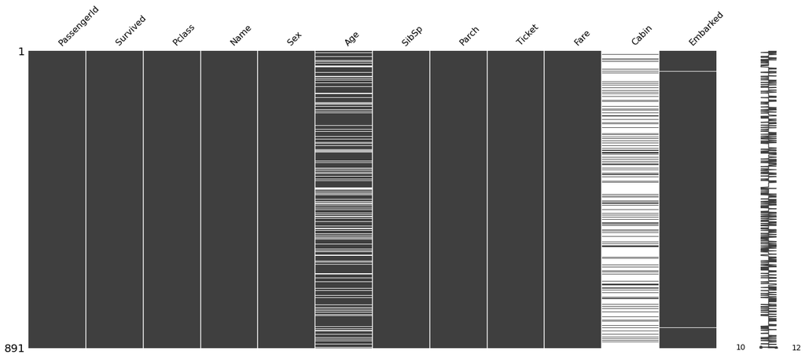

```python
import missingno as msno

msno.matrix(train)
plt.show()
```

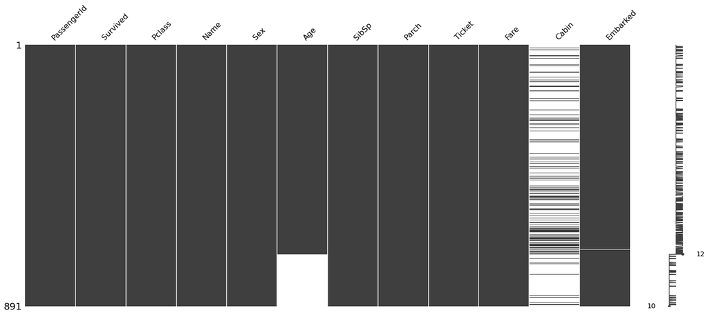

```python
# Sorted by Age untuk mengecek apakah ada korelasi missing value dengan kolom missing lainnya
sorted = train.sort_values('Age')
msno.matrix(sorted)
plt.show()
```

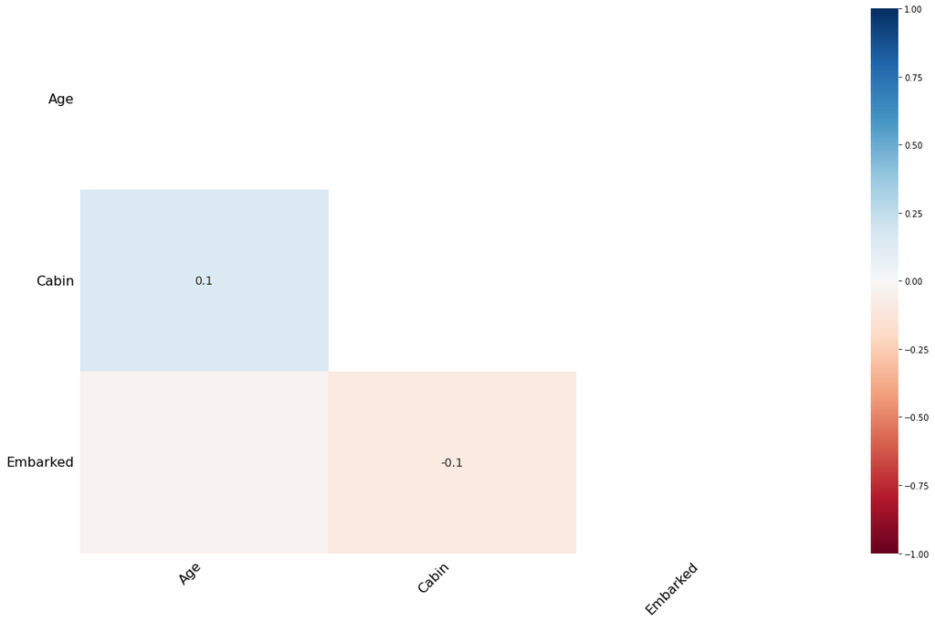

```python
# Mengecek korelasi antar missing values
msno.heatmap(train)
plt.show()
```

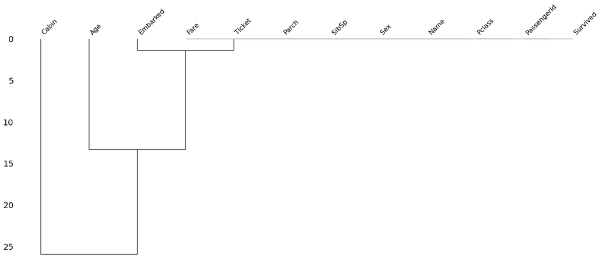

```python
msno.dendrogram(train)
plt.show()
```

```python
percent_missing = round(train_pre_ft.isnull().sum()*100/len(train_pre_ft),2)
missing_value = pd.DataFrame({'column':train_pre_ft.columns,'percent_missing':percent_missing})
missing_value = missing_value[missing_value['percent_missing']>0]
missing_value = missing_value.sort_values('percent_missing', ascending=False)
missing_value
```

|  | column | percent_missing |
| --- | --- | --- |
| Cabin_C65 | Cabin_C65 | 77.10 |
| Cabin_D49 | Cabin_D49 | 77.10 |
| Cabin_D15 | Cabin_D15 | 77.10 |
| Cabin_D17 | Cabin_D17 | 77.10 |
| Cabin_D19 | Cabin_D19 | 77.10 |
| Cabin_D20 | Cabin_D20 | 77.10 |
| Cabin_D21 | Cabin_D21 | 77.10 |
| Cabin_D26 | Cabin_D26 | 77.10 |
| Cabin_D28 | Cabin_D28 | 77.10 |
| Cabin_D30 | Cabin_D30 | 77.10 |
| Cabin_D33 | Cabin_D33 | 77.10 |
| Cabin_D35 | Cabin_D35 | 77.10 |
| Cabin_D36 | Cabin_D36 | 77.10 |
| Cabin_D37 | Cabin_D37 | 77.10 |
| Cabin_D45 | Cabin_D45 | 77.10 |
| Cabin_D46 | Cabin_D46 | 77.10 |
| Cabin_D47 | Cabin_D47 | 77.10 |
| Cabin_D11 | Cabin_D11 | 77.10 |
| Cabin_D10 D12 | Cabin_D10 D12 | 77.10 |
| Cabin_D | Cabin_D | 77.10 |
| Cabin_C85 | Cabin_C85 | 77.10 |
| Cabin_C68 | Cabin_C68 | 77.10 |
| Cabin_C7 | Cabin_C7 | 77.10 |
| Cabin_C70 | Cabin_C70 | 77.10 |
| Cabin_C78 | Cabin_C78 | 77.10 |
| Cabin_C82 | Cabin_C82 | 77.10 |
| Cabin_C83 | Cabin_C83 | 77.10 |
| Cabin_C86 | Cabin_C86 | 77.10 |
| Cabin_C99 | Cabin_C99 | 77.10 |
| Cabin_C87 | Cabin_C87 | 77.10 |

[output cut: 121 more lines]

Cabin didrop karena lebih dari 70%,

Age diimputasi numerikal karena diantara 70% dan 10%

Embarked diimputasi dengan modus karena dibawah 10%

```python
train_miss = train_pre_ft.drop(missing_value[missing_value['percent_missing']>70]['column'], axis=1)
train_miss.head()
```

|  | Age | Fare | Survived_0.0 | Survived_1.0 | Pclass_1.0 | Pclass_2.0 | Pclass_3.0 | Sex_female | Sex_male | SibSp_0.0 | SibSp_1.0 | SibSp_2.0 | SibSp_3.0 | SibSp_4.0 | SibSp_5.0 | SibSp_8.0 | Parch_0.0 | Parch_1.0 | Parch_2.0 | Parch_3.0 | Parch_4.0 | Parch_5.0 | Parch_6.0 | Embarked_C | Embarked_Q | Embarked_S |
| --- | --- | --- | --- | --- | --- | --- | --- | --- | --- | --- | --- | --- | --- | --- | --- | --- | --- | --- | --- | --- | --- | --- | --- | --- | --- | --- |
| 0 | 0.370310 | 0.350808 | 1 | 0 | 0 | 0 | 1 | 0 | 1 | 0 | 1 | 0 | 0 | 0 | 0 | 0 | 1 | 0 | 0 | 0 | 0 | 0 | 0 | 0.0 | 0.0 | 1.0 |
| 1 | 0.639657 | 0.753358 | 0 | 1 | 1 | 0 | 0 | 1 | 0 | 0 | 1 | 0 | 0 | 0 | 0 | 0 | 1 | 0 | 0 | 0 | 0 | 0 | 0 | 1.0 | 0.0 | 0.0 |
| 2 | 0.436668 | 0.354978 | 0 | 1 | 0 | 0 | 1 | 1 | 0 | 1 | 0 | 0 | 0 | 0 | 0 | 0 | 1 | 0 | 0 | 0 | 0 | 0 | 0 | 0.0 | 0.0 | 1.0 |
| 3 | 0.590669 | 0.651297 | 0 | 1 | 1 | 0 | 0 | 1 | 0 | 0 | 1 | 0 | 0 | 0 | 0 | 0 | 1 | 0 | 0 | 0 | 0 | 0 | 0 | 0.0 | 0.0 | 1.0 |
| 4 | 0.590669 | 0.355752 | 1 | 0 | 0 | 0 | 1 | 0 | 1 | 1 | 0 | 0 | 0 | 0 | 0 | 0 | 1 | 0 | 0 | 0 | 0 | 0 | 0 | 0.0 | 0.0 | 1.0 |

### Teknik Imputasi

Imputasi dengan kombinasi metode *Winsorization* lebih disarankan daripada *Trimming* (baris atau fitur didrop) karena untuk analisis prediktif lebih baik jika punya lebih banyak data

#### Imputasi Sederhana

```python
train_SI_imputed = train_miss.copy(deep=True)
```

```python
from sklearn.impute import SimpleImputer

SI = SimpleImputer(missing_values=np.nan, strategy="median")
train_SI = SI.fit_transform(train_miss)
```

```python
train_SI_imputed[train_SI_imputed.columns] = train_SI
train_SI_imputed.head()
```

|  | Age | Fare | Survived_0.0 | Survived_1.0 | Pclass_1.0 | Pclass_2.0 | Pclass_3.0 | Sex_female | Sex_male | SibSp_0.0 | SibSp_1.0 | SibSp_2.0 | SibSp_3.0 | SibSp_4.0 | SibSp_5.0 | SibSp_8.0 | Parch_0.0 | Parch_1.0 | Parch_2.0 | Parch_3.0 | Parch_4.0 | Parch_5.0 | Parch_6.0 | Embarked_C | Embarked_Q | Embarked_S |
| --- | --- | --- | --- | --- | --- | --- | --- | --- | --- | --- | --- | --- | --- | --- | --- | --- | --- | --- | --- | --- | --- | --- | --- | --- | --- | --- |
| 0 | 0.370310 | 0.350808 | 1.0 | 0.0 | 0.0 | 0.0 | 1.0 | 0.0 | 1.0 | 0.0 | 1.0 | 0.0 | 0.0 | 0.0 | 0.0 | 0.0 | 1.0 | 0.0 | 0.0 | 0.0 | 0.0 | 0.0 | 0.0 | 0.0 | 0.0 | 1.0 |
| 1 | 0.639657 | 0.753358 | 0.0 | 1.0 | 1.0 | 0.0 | 0.0 | 1.0 | 0.0 | 0.0 | 1.0 | 0.0 | 0.0 | 0.0 | 0.0 | 0.0 | 1.0 | 0.0 | 0.0 | 0.0 | 0.0 | 0.0 | 0.0 | 1.0 | 0.0 | 0.0 |
| 2 | 0.436668 | 0.354978 | 0.0 | 1.0 | 0.0 | 0.0 | 1.0 | 1.0 | 0.0 | 1.0 | 0.0 | 0.0 | 0.0 | 0.0 | 0.0 | 0.0 | 1.0 | 0.0 | 0.0 | 0.0 | 0.0 | 0.0 | 0.0 | 0.0 | 0.0 | 1.0 |
| 3 | 0.590669 | 0.651297 | 0.0 | 1.0 | 1.0 | 0.0 | 0.0 | 1.0 | 0.0 | 0.0 | 1.0 | 0.0 | 0.0 | 0.0 | 0.0 | 0.0 | 1.0 | 0.0 | 0.0 | 0.0 | 0.0 | 0.0 | 0.0 | 0.0 | 0.0 | 1.0 |
| 4 | 0.590669 | 0.355752 | 1.0 | 0.0 | 0.0 | 0.0 | 1.0 | 0.0 | 1.0 | 1.0 | 0.0 | 0.0 | 0.0 | 0.0 | 0.0 | 0.0 | 1.0 | 0.0 | 0.0 | 0.0 | 0.0 | 0.0 | 0.0 | 0.0 | 0.0 | 1.0 |

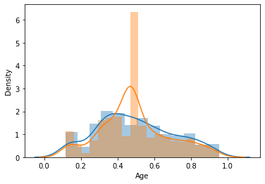

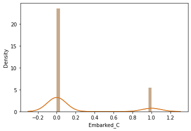

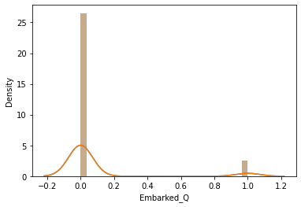

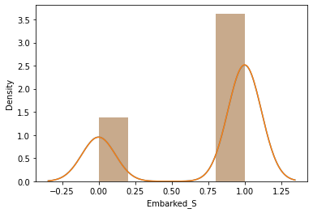

```python
for column in train_miss.columns:
  sns.distplot(train_miss[column])
  sns.distplot(train_SI_imputed[column])
  plt.show()
```

#### MICE (Multiple Imputation by Chained Equations)

```python
!pip install impyute
```

```python
train_mice_imputed = train_miss.copy(deep=True)
```

```python
train_miss = train_miss.astype('float64')
train_miss.head()
```

|  | Age | Fare | Survived_0.0 | Survived_1.0 | Pclass_1.0 | Pclass_2.0 | Pclass_3.0 | Sex_female | Sex_male | SibSp_0.0 | SibSp_1.0 | SibSp_2.0 | SibSp_3.0 | SibSp_4.0 | SibSp_5.0 | SibSp_8.0 | Parch_0.0 | Parch_1.0 | Parch_2.0 | Parch_3.0 | Parch_4.0 | Parch_5.0 | Parch_6.0 | Embarked_C | Embarked_Q | Embarked_S |
| --- | --- | --- | --- | --- | --- | --- | --- | --- | --- | --- | --- | --- | --- | --- | --- | --- | --- | --- | --- | --- | --- | --- | --- | --- | --- | --- |
| 0 | 0.370310 | 0.350808 | 1.0 | 0.0 | 0.0 | 0.0 | 1.0 | 0.0 | 1.0 | 0.0 | 1.0 | 0.0 | 0.0 | 0.0 | 0.0 | 0.0 | 1.0 | 0.0 | 0.0 | 0.0 | 0.0 | 0.0 | 0.0 | 0.0 | 0.0 | 1.0 |
| 1 | 0.639657 | 0.753358 | 0.0 | 1.0 | 1.0 | 0.0 | 0.0 | 1.0 | 0.0 | 0.0 | 1.0 | 0.0 | 0.0 | 0.0 | 0.0 | 0.0 | 1.0 | 0.0 | 0.0 | 0.0 | 0.0 | 0.0 | 0.0 | 1.0 | 0.0 | 0.0 |
| 2 | 0.436668 | 0.354978 | 0.0 | 1.0 | 0.0 | 0.0 | 1.0 | 1.0 | 0.0 | 1.0 | 0.0 | 0.0 | 0.0 | 0.0 | 0.0 | 0.0 | 1.0 | 0.0 | 0.0 | 0.0 | 0.0 | 0.0 | 0.0 | 0.0 | 0.0 | 1.0 |
| 3 | 0.590669 | 0.651297 | 0.0 | 1.0 | 1.0 | 0.0 | 0.0 | 1.0 | 0.0 | 0.0 | 1.0 | 0.0 | 0.0 | 0.0 | 0.0 | 0.0 | 1.0 | 0.0 | 0.0 | 0.0 | 0.0 | 0.0 | 0.0 | 0.0 | 0.0 | 1.0 |
| 4 | 0.590669 | 0.355752 | 1.0 | 0.0 | 0.0 | 0.0 | 1.0 | 0.0 | 1.0 | 1.0 | 0.0 | 0.0 | 0.0 | 0.0 | 0.0 | 0.0 | 1.0 | 0.0 | 0.0 | 0.0 | 0.0 | 0.0 | 0.0 | 0.0 | 0.0 | 1.0 |

```python
'''
Jika kolom ingin didefinisikan maka bisa dipakai kode dibawah ini
train_miss_num = train_miss.loc[:,['Age','Fare']].astype('float64')
train_num_mice = mice(train_miss['Age'].values)
'''
```

```
"\nJika kolom ingin didefinisikan maka bisa dipakai kode dibawah ini\ntrain_miss_num = train_miss.loc[:,['Age','Fare']].astype('float64')\ntrain_num_mice = mice(train_miss['Age'].values)\n"
```

```python
%%time
from impyute.imputation.cs import mice

train_mice = mice(train_miss.values)
```

```
CPU times: user 207 ms, sys: 140 ms, total: 347 ms
Wall time: 206 ms
```

```python
train_mice_imputed[train_mice_imputed.columns] = train_mice
train_mice_imputed.head()
```

|  | Age | Fare | Survived_0.0 | Survived_1.0 | Pclass_1.0 | Pclass_2.0 | Pclass_3.0 | Sex_female | Sex_male | SibSp_0.0 | SibSp_1.0 | SibSp_2.0 | SibSp_3.0 | SibSp_4.0 | SibSp_5.0 | SibSp_8.0 | Parch_0.0 | Parch_1.0 | Parch_2.0 | Parch_3.0 | Parch_4.0 | Parch_5.0 | Parch_6.0 | Embarked_C | Embarked_Q | Embarked_S |
| --- | --- | --- | --- | --- | --- | --- | --- | --- | --- | --- | --- | --- | --- | --- | --- | --- | --- | --- | --- | --- | --- | --- | --- | --- | --- | --- |
| 0 | 0.370310 | 0.350808 | 1.0 | 0.0 | 0.0 | 0.0 | 1.0 | 0.0 | 1.0 | 0.0 | 1.0 | 0.0 | 0.0 | 0.0 | 0.0 | 0.0 | 1.0 | 0.0 | 0.0 | 0.0 | 0.0 | 0.0 | 0.0 | 0.0 | 0.0 | 1.0 |
| 1 | 0.639657 | 0.753358 | 0.0 | 1.0 | 1.0 | 0.0 | 0.0 | 1.0 | 0.0 | 0.0 | 1.0 | 0.0 | 0.0 | 0.0 | 0.0 | 0.0 | 1.0 | 0.0 | 0.0 | 0.0 | 0.0 | 0.0 | 0.0 | 1.0 | 0.0 | 0.0 |
| 2 | 0.436668 | 0.354978 | 0.0 | 1.0 | 0.0 | 0.0 | 1.0 | 1.0 | 0.0 | 1.0 | 0.0 | 0.0 | 0.0 | 0.0 | 0.0 | 0.0 | 1.0 | 0.0 | 0.0 | 0.0 | 0.0 | 0.0 | 0.0 | 0.0 | 0.0 | 1.0 |
| 3 | 0.590669 | 0.651297 | 0.0 | 1.0 | 1.0 | 0.0 | 0.0 | 1.0 | 0.0 | 0.0 | 1.0 | 0.0 | 0.0 | 0.0 | 0.0 | 0.0 | 1.0 | 0.0 | 0.0 | 0.0 | 0.0 | 0.0 | 0.0 | 0.0 | 0.0 | 1.0 |
| 4 | 0.590669 | 0.355752 | 1.0 | 0.0 | 0.0 | 0.0 | 1.0 | 0.0 | 1.0 | 1.0 | 0.0 | 0.0 | 0.0 | 0.0 | 0.0 | 0.0 | 1.0 | 0.0 | 0.0 | 0.0 | 0.0 | 0.0 | 0.0 | 0.0 | 0.0 | 1.0 |

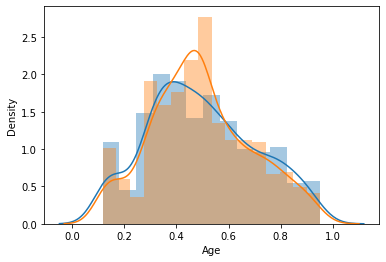

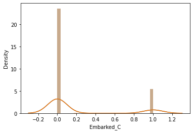

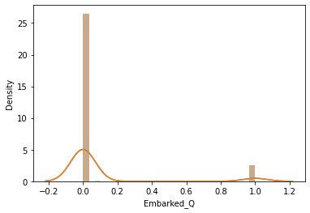

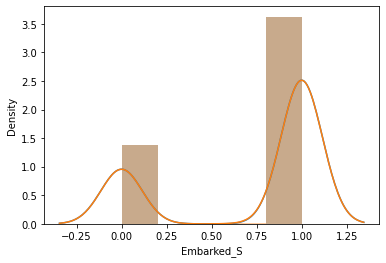

```python
for column in train_miss.columns:
  sns.distplot(train_miss[column])
  sns.distplot(train_mice_imputed[column])
  plt.show()
```

#### K-Nearest Neighbor Imputation

[figure not shown]

```python
train_KNN_imputed = train_miss.copy(deep=True)
```

```python
%%time
from sklearn.impute import KNNImputer

imputer = KNNImputer(n_neighbors=1)
train_KNN = imputer.fit_transform(train_miss)
```

```
CPU times: user 32.7 ms, sys: 20.2 ms, total: 52.9 ms
Wall time: 31.1 ms
```

```python
'''
Untuk satu kolom, bisa menggunakan contoh dibawah ini
train_num_KNN = imputer.fit_transform(train_miss['Embarked'].values.reshape(-1,1))
'''
```

```
"\nUntuk satu kolom, bisa menggunakan contoh dibawah ini\ntrain_num_KNN = imputer.fit_transform(train_miss['Embarked'].values.reshape(-1,1))\n"
```

```python
train_KNN_imputed[train_KNN_imputed.columns] = train_KNN
train_KNN_imputed.head()
```

|  | Age | Fare | Survived_0.0 | Survived_1.0 | Pclass_1.0 | Pclass_2.0 | Pclass_3.0 | Sex_female | Sex_male | SibSp_0.0 | SibSp_1.0 | SibSp_2.0 | SibSp_3.0 | SibSp_4.0 | SibSp_5.0 | SibSp_8.0 | Parch_0.0 | Parch_1.0 | Parch_2.0 | Parch_3.0 | Parch_4.0 | Parch_5.0 | Parch_6.0 | Embarked_C | Embarked_Q | Embarked_S |
| --- | --- | --- | --- | --- | --- | --- | --- | --- | --- | --- | --- | --- | --- | --- | --- | --- | --- | --- | --- | --- | --- | --- | --- | --- | --- | --- |
| 0 | 0.370310 | 0.350808 | 1.0 | 0.0 | 0.0 | 0.0 | 1.0 | 0.0 | 1.0 | 0.0 | 1.0 | 0.0 | 0.0 | 0.0 | 0.0 | 0.0 | 1.0 | 0.0 | 0.0 | 0.0 | 0.0 | 0.0 | 0.0 | 0.0 | 0.0 | 1.0 |
| 1 | 0.639657 | 0.753358 | 0.0 | 1.0 | 1.0 | 0.0 | 0.0 | 1.0 | 0.0 | 0.0 | 1.0 | 0.0 | 0.0 | 0.0 | 0.0 | 0.0 | 1.0 | 0.0 | 0.0 | 0.0 | 0.0 | 0.0 | 0.0 | 1.0 | 0.0 | 0.0 |
| 2 | 0.436668 | 0.354978 | 0.0 | 1.0 | 0.0 | 0.0 | 1.0 | 1.0 | 0.0 | 1.0 | 0.0 | 0.0 | 0.0 | 0.0 | 0.0 | 0.0 | 1.0 | 0.0 | 0.0 | 0.0 | 0.0 | 0.0 | 0.0 | 0.0 | 0.0 | 1.0 |
| 3 | 0.590669 | 0.651297 | 0.0 | 1.0 | 1.0 | 0.0 | 0.0 | 1.0 | 0.0 | 0.0 | 1.0 | 0.0 | 0.0 | 0.0 | 0.0 | 0.0 | 1.0 | 0.0 | 0.0 | 0.0 | 0.0 | 0.0 | 0.0 | 0.0 | 0.0 | 1.0 |
| 4 | 0.590669 | 0.355752 | 1.0 | 0.0 | 0.0 | 0.0 | 1.0 | 0.0 | 1.0 | 1.0 | 0.0 | 0.0 | 0.0 | 0.0 | 0.0 | 0.0 | 1.0 | 0.0 | 0.0 | 0.0 | 0.0 | 0.0 | 0.0 | 0.0 | 0.0 | 1.0 |

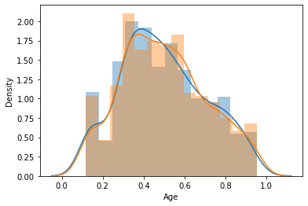

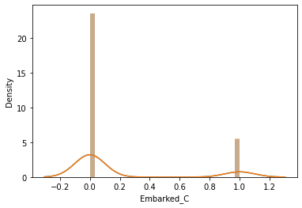

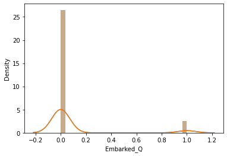

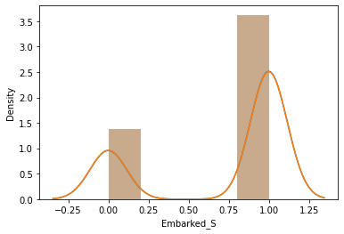

```python
for column in train_miss.columns:
  sns.distplot(train_miss[column])
  sns.distplot(train_KNN_imputed[column])
  plt.show()
```

### Kompilasi Hasil *Pre-Processing Missing Value*

```python
train_imputed = train_KNN_imputed.copy(deep=True)
```

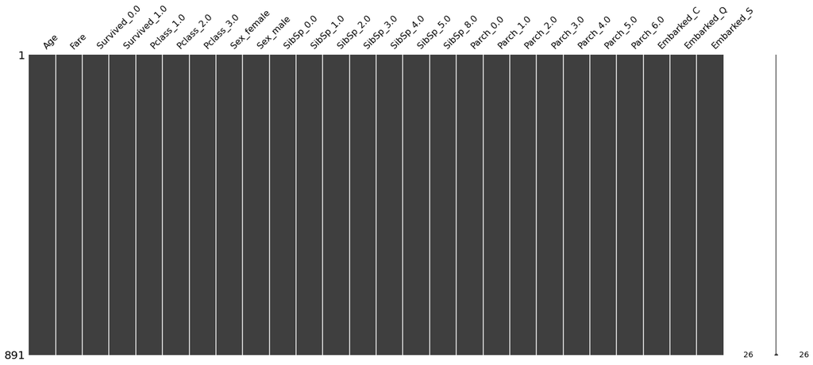

```python
import missingno as msno

msno.matrix(train_imputed)
plt.show()
```

## Seleksi Fitur dan Label

```python
train_X = train_imputed.drop(labels=['Survived_0.0',	'Survived_1.0'], axis=1)
train_y = train_imputed[['Survived_0.0',	'Survived_1.0']]
```

```python
train_X.head()
```

|  | Age | Fare | Pclass_1.0 | Pclass_2.0 | Pclass_3.0 | Sex_female | Sex_male | SibSp_0.0 | SibSp_1.0 | SibSp_2.0 | SibSp_3.0 | SibSp_4.0 | SibSp_5.0 | SibSp_8.0 | Parch_0.0 | Parch_1.0 | Parch_2.0 | Parch_3.0 | Parch_4.0 | Parch_5.0 | Parch_6.0 | Embarked_C | Embarked_Q | Embarked_S |
| --- | --- | --- | --- | --- | --- | --- | --- | --- | --- | --- | --- | --- | --- | --- | --- | --- | --- | --- | --- | --- | --- | --- | --- | --- |
| 0 | 0.370310 | 0.350808 | 0.0 | 0.0 | 1.0 | 0.0 | 1.0 | 0.0 | 1.0 | 0.0 | 0.0 | 0.0 | 0.0 | 0.0 | 1.0 | 0.0 | 0.0 | 0.0 | 0.0 | 0.0 | 0.0 | 0.0 | 0.0 | 1.0 |
| 1 | 0.639657 | 0.753358 | 1.0 | 0.0 | 0.0 | 1.0 | 0.0 | 0.0 | 1.0 | 0.0 | 0.0 | 0.0 | 0.0 | 0.0 | 1.0 | 0.0 | 0.0 | 0.0 | 0.0 | 0.0 | 0.0 | 1.0 | 0.0 | 0.0 |
| 2 | 0.436668 | 0.354978 | 0.0 | 0.0 | 1.0 | 1.0 | 0.0 | 1.0 | 0.0 | 0.0 | 0.0 | 0.0 | 0.0 | 0.0 | 1.0 | 0.0 | 0.0 | 0.0 | 0.0 | 0.0 | 0.0 | 0.0 | 0.0 | 1.0 |
| 3 | 0.590669 | 0.651297 | 1.0 | 0.0 | 0.0 | 1.0 | 0.0 | 0.0 | 1.0 | 0.0 | 0.0 | 0.0 | 0.0 | 0.0 | 1.0 | 0.0 | 0.0 | 0.0 | 0.0 | 0.0 | 0.0 | 0.0 | 0.0 | 1.0 |
| 4 | 0.590669 | 0.355752 | 0.0 | 0.0 | 1.0 | 0.0 | 1.0 | 1.0 | 0.0 | 0.0 | 0.0 | 0.0 | 0.0 | 0.0 | 1.0 | 0.0 | 0.0 | 0.0 | 0.0 | 0.0 | 0.0 | 0.0 | 0.0 | 1.0 |

```python
train_y.head()
```

|  | Survived_0.0 | Survived_1.0 |
| --- | --- | --- |
| 0 | 1.0 | 0.0 |
| 1 | 0.0 | 1.0 |
| 2 | 0.0 | 1.0 |
| 3 | 0.0 | 1.0 |
| 4 | 1.0 | 0.0 |

# *Exploratory Data Analysis: Finding Descriptive Insight*

### Analisis Multivariat

#### Reg Plot

##### *Numerical Column Correlation*

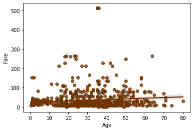

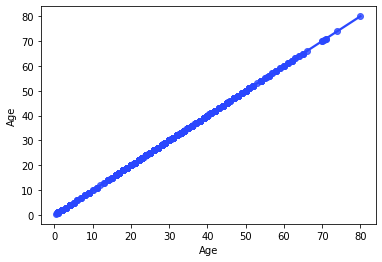

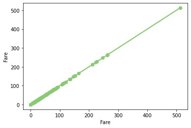

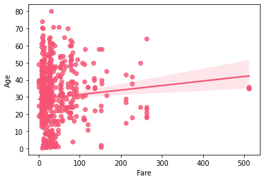

```python
import random

def random_color():
    return "#{}{}{}{}{}{}".format(*(random.choice("0123456789abcdef") for _ in range(6)))

colors = [random_color() for _ in range(2*len(train_num.columns.unique()))]
count = 0
for column_num in train_num.columns:
  for column_num_rev in reversed(train_num.columns):
    sns.regplot(x=column_num, y=column_num_rev, data=train, color=colors[count])
    plt.show()
    count += 1
```

#### Scatter

##### *Numerical Column Correlation*

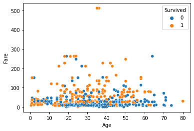

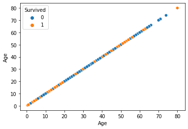

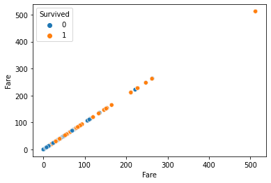

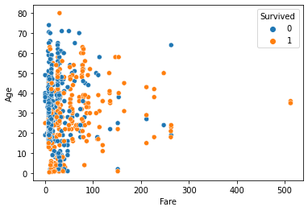

```python
for column_num in train_num.columns:
  for column_num_rev in reversed(train_num.columns):
    sns.scatterplot(x=column_num, y=column_num_rev, data=train, hue='Survived')
    plt.show()
```